# Analysis 1 with permutation tests: which measures predict name-sharing?

This notebook reports permutation tests for Analysis 1. It reads the cached results written by `perm_analyses/run_perm.R` and does no model fitting itself. See `perm_analyses/README.md` for the design.

```r
library(tidyverse)
library(here)
library(knitr)
library(kableExtra)

out_dir <- here("perm_analyses", "output", if (params$quick) "quick" else "")
source(here("perm_analyses", "perm_functions.R"))

lang_order <- c(languages, "All")
test_order <- sapply(perm_tests, `[[`, "test")

res <- readRDS(file.path(out_dir, "perm_tests.rds")) %>%
  mutate(language = factor(language, lang_order),
         test = factor(test, test_order))
boot <- readRDS(file.path(out_dir, "boot_74v23.rds"))
cal <- readRDS(file.path(out_dir, "calibration.rds"))
run_info <- readLines(file.path(out_dir, "run_info.txt"))
B <- length(res$null[[1]])

fmt <- function(x, d = 1) formatC(x, format = "f", digits = d)
fmt_p <- function(p) ifelse(p < .001, "<.001", formatC(p, format = "f", digits = 3))
```

Settings: B 2000, B_boot 2000, R_cal 100, B_cal 199, seed 302.

# How the tests work

The outcome is the species × species matrix of `SameName`. It is never changed, so all the dependence between pairs is kept: each species appears in many pairs, and if A and B share a name and B and C do, then A and C must too.

This is MRQAP with double-semi-partialling (Dekker, Krackhardt & Snijders, 2007). With Z empty it is plain QAP, which is the same as shuffling species among the folk categories while keeping their sizes fixed.

For the non-nested comparisons (74 vs 23, Per vs Phy), each measure is tested given the other in both directions. If 74 adds to 23 but 23 adds nothing to 74, then 74 is the better measure. If each adds to the other, then each carries something the other lacks, and the test doesn’t pick a winner.

“All” is a pooled model with a fixed intercept for each language and common slopes. Species are relabelled within each language.

# Calibration

Before the results: does the test have the right false-positive rate? For each language, 100 “noise” predictors were made by shuffling the species labels of the Per matrix. Each one has the matrix structure of a real distance measure but no true relation to naming. Each was tested given 74, by MRQAP and by the naive Wald test from the logistic regression, which treats pairs as independent, as BIC does.

```r
cal_tab <- cal %>%
  mutate(language = factor(language, languages)) %>%
  group_by(language) %>%
  summarise(`MRQAP (%)` = 100 * mean(p_mrqap < .05),
            `Naive Wald (%)` = 100 * mean(p_naive < .05), .groups = "drop") %>%
  bind_rows(tibble(language = factor("All languages"),
                   `MRQAP (%)` = 100 * mean(cal$p_mrqap < .05),
                   `Naive Wald (%)` = 100 * mean(cal$p_naive < .05)))
write.csv(cal_tab, file.path(out_dir, "table_calibration.csv"), row.names = FALSE)
kable(cal_tab, digits = 1,
      caption = "Percentage of noise predictors declared significant at α = .05 (nominal rate 5%)") %>%
  kable_styling(full_width = FALSE)
```

Percentage of noise predictors declared significant at α = .05 (nominal rate 5%)

| language | MRQAP (%) | Naive Wald (%) |
| --- | --- | --- |
| Anindilyakwa | 1 | 30.0 |
| Innu | 8 | 19.0 |
| Saami | 5 | 24.0 |
| Tlingit | 2 | 17.0 |
| Tobelo | 8 | 16.0 |
| Tzeltal | 5 | 29.0 |
| Zapotec | 6 | 29.0 |
| All languages | 5 | 23.4 |

The naive test treats thousands of dependent pairs as independent, so it finds “effects” of pure noise far more often than 5% of the time. This is issue A1 in `REVIEW.md` in concrete form. The BIC comparisons in the paper have the same problem.

# Results

Each cell shows the observed statistic s, with the two-sided permutation p-value in brackets. The smallest possible p-value is 1/(B + 1) = 0.0005. Negative s means the measure’s slope has the “wrong” sign: given Z, *more* distant birds are *more* likely to share a name.

```r
res_wide <- res %>%
  mutate(cell = paste0(fmt(s_obs), " (", fmt_p(p_two), ")")) %>%
  select(question, test, language, cell) %>%
  pivot_wider(names_from = language, values_from = cell) %>%
  arrange(test)

write.csv(select(res, -null), file.path(out_dir, "table_perm.csv"),
          row.names = FALSE)

kable(select(res_wide, -question), align = c("l", rep("r", length(lang_order))),
      caption = "Signed root deviance gain s (two-sided permutation p)") %>%
  kable_styling(full_width = FALSE) %>%
  pack_rows("(a) Does the measure predict naming at all?", 1, 4) %>%
  pack_rows("(b) Does the measure add to the others?", 5, 9) %>%
  pack_rows("(c) Non-nested comparisons, tested both ways", 10, 13)
```

Signed root deviance gain s (two-sided permutation p)

| test | Anindilyakwa | Innu | Saami | Tlingit | Tobelo | Tzeltal | Zapotec | All |
| --- | --- | --- | --- | --- | --- | --- | --- | --- |
| **(a) Does the measure predict naming at all?** |  |  |  |  |  |  |  |  |
| 74 | 42.2 (<.001) | 21.1 (<.001) | 14.3 (<.001) | 22.6 (<.001) | 20.2 (<.001) | 40.3 (<.001) | 35.6 (<.001) | 77.2 (<.001) |
| 23 | 41.0 (<.001) | 20.6 (<.001) | 12.4 (<.001) | 21.6 (<.001) | 20.1 (<.001) | 40.5 (<.001) | 35.5 (<.001) | 75.7 (<.001) |
| Phy | 35.8 (<.001) | 17.6 (<.001) | 10.4 (<.001) | 18.3 (<.001) | 14.5 (<.001) | 31.2 (<.001) | 27.4 (<.001) | 61.9 (<.001) |
| Per | 37.8 (<.001) | 15.0 (<.001) | 9.6 (<.001) | 19.7 (<.001) | 16.9 (<.001) | 32.9 (<.001) | 30.5 (<.001) | 65.3 (<.001) |
| **(b) Does the measure add to the others?** |  |  |  |  |  |  |  |  |
| Per &#124; 74 | 16.8 (<.001) | 1.4 (0.328) | 1.7 (0.304) | 7.4 (<.001) | 5.7 (<.001) | 9.7 (<.001) | 11.3 (<.001) | 23.8 (<.001) |
| Phy &#124; 74 | 2.9 (0.149) | -4.0 (0.004) | -6.4 (<.001) | -1.5 (0.326) | -4.0 (0.002) | 3.1 (0.092) | -2.8 (0.107) | -2.5 (0.174) |
| Phy &#124; 74+Per | 1.4 (0.476) | -4.2 (0.002) | -6.6 (<.001) | -2.7 (0.062) | -5.1 (<.001) | -0.2 (0.921) | -4.8 (0.009) | -5.9 (0.002) |
| Per &#124; 74+Phy | 16.6 (<.001) | 2.0 (0.143) | 2.4 (0.122) | 7.8 (<.001) | 6.5 (<.001) | 9.2 (<.001) | 11.9 (<.001) | 24.4 (<.001) |
| 74 &#124; Phy+Per | 15.1 (<.001) | 11.1 (<.001) | 10.9 (<.001) | 10.2 (<.001) | 11.5 (<.001) | 19.6 (<.001) | 18.3 (<.001) | 35.2 (<.001) |
| **(c) Non-nested comparisons, tested both ways** |  |  |  |  |  |  |  |  |
| 74 &#124; 23 | 10.1 (<.001) | 4.5 (<.001) | 9.7 (<.001) | 6.9 (<.001) | 3.2 (0.001) | 5.5 (<.001) | 5.2 (<.001) | 16.1 (<.001) |
| 23 &#124; 74 | 2.4 (0.054) | 0.3 (0.738) | -6.6 (<.001) | -2.3 (0.030) | 1.9 (0.047) | 7.2 (<.001) | 4.1 (<.001) | 4.9 (<.001) |
| Per &#124; Phy | 23.5 (<.001) | 5.5 (<.001) | 4.9 (0.002) | 11.6 (<.001) | 11.2 (<.001) | 19.0 (<.001) | 18.3 (<.001) | 38.7 (<.001) |
| Phy &#124; Per | 20.2 (<.001) | 10.7 (<.001) | 6.4 (<.001) | 9.1 (<.001) | 7.1 (<.001) | 15.7 (<.001) | 12.5 (<.001) | 32.7 (<.001) |

```r
latex_perm <- select(res_wide, -question) %>%
  kable(format = "latex", booktabs = TRUE, linesep = "",
        align = c("l", rep("r", length(lang_order))),
        caption = "Permutation tests for Analysis 1: signed root deviance gain (two-sided p)") %>%
  pack_rows("(a) Overall effect", 1, 4) %>%
  pack_rows("(b) Added value", 5, 9) %>%
  pack_rows("(c) Non-nested, both directions", 10, 13) %>%
  kable_styling(latex_options = c("hold_position", "scale_down"))
writeLines(latex_perm, file.path(out_dir, "table_perm.tex"))
```

## Naive p-values for comparison

The same tests, with p-values from the naive Wald test. The permutation p-values are much larger.

```r
res %>%
  mutate(cell = paste0(fmt_p(p_two), " / ", formatC(p_naive, format = "e", digits = 0))) %>%
  select(test, language, cell) %>%
  pivot_wider(names_from = language, values_from = cell) %>%
  arrange(test) %>%
  kable(align = c("l", rep("r", length(lang_order))),
        caption = "Permutation p / naive Wald p (two-sided)") %>%
  kable_styling(full_width = FALSE)
```

Permutation p / naive Wald p (two-sided)

| test | Anindilyakwa | Innu | Saami | Tlingit | Tobelo | Tzeltal | Zapotec | All |
| --- | --- | --- | --- | --- | --- | --- | --- | --- |
| 74 | <.001 / 1e-293 | <.001 / 2e-56 | <.001 / 2e-35 | <.001 / 4e-55 | <.001 / 1e-52 | <.001 / 6e-68 | <.001 / 5e-159 | <.001 / 0e+00 |
| 23 | <.001 / 8e-289 | <.001 / 6e-57 | <.001 / 1e-32 | <.001 / 2e-57 | <.001 / 1e-53 | <.001 / 2e-78 | <.001 / 8e-162 | <.001 / 0e+00 |
| Phy | <.001 / 1e-252 | <.001 / 5e-49 | <.001 / 2e-25 | <.001 / 7e-51 | <.001 / 3e-46 | <.001 / 2e-84 | <.001 / 2e-126 | <.001 / 0e+00 |
| Per | <.001 / 1e-166 | <.001 / 5e-32 | <.001 / 1e-14 | <.001 / 2e-42 | <.001 / 3e-32 | <.001 / 3e-87 | <.001 / 4e-86 | <.001 / 0e+00 |
| Per &#124; 74 | <.001 / 2e-44 | 0.328 / 2e-01 | 0.304 / 1e-01 | <.001 / 5e-10 | <.001 / 1e-06 | <.001 / 3e-15 | <.001 / 1e-21 | <.001 / 4e-91 |
| Phy &#124; 74 | 0.149 / 3e-03 | 0.004 / 2e-04 | <.001 / 2e-08 | 0.326 / 1e-01 | 0.002 / 1e-04 | 0.092 / 2e-03 | 0.107 / 5e-03 | 0.174 / 1e-02 |
| Phy &#124; 74+Per | 0.476 / 2e-01 | 0.002 / 7e-05 | <.001 / 7e-09 | 0.062 / 8e-03 | <.001 / 2e-06 | 0.921 / 8e-01 | 0.009 / 2e-06 | 0.002 / 5e-09 |
| Per &#124; 74+Phy | <.001 / 8e-44 | 0.143 / 5e-02 | 0.122 / 3e-02 | <.001 / 1e-10 | <.001 / 1e-07 | <.001 / 3e-14 | <.001 / 1e-23 | <.001 / 7e-95 |
| 74 &#124; Phy+Per | <.001 / 2e-46 | <.001 / 1e-19 | <.001 / 2e-19 | <.001 / 1e-20 | <.001 / 6e-23 | <.001 / 3e-37 | <.001 / 1e-56 | <.001 / 2e-221 |
| 74 &#124; 23 | <.001 / 6e-25 | <.001 / 2e-06 | <.001 / 1e-23 | <.001 / 3e-11 | 0.001 / 8e-04 | <.001 / 3e-08 | <.001 / 1e-08 | <.001 / 2e-63 |
| 23 &#124; 74 | 0.054 / 2e-02 | 0.738 / 8e-01 | <.001 / 3e-13 | 0.030 / 2e-02 | 0.047 / 7e-02 | <.001 / 2e-08 | <.001 / 1e-04 | <.001 / 2e-06 |
| Per &#124; Phy | <.001 / 9e-77 | <.001 / 8e-07 | 0.002 / 2e-05 | <.001 / 2e-19 | <.001 / 6e-17 | <.001 / 6e-41 | <.001 / 2e-46 | <.001 / 2e-203 |
| Phy &#124; Per | <.001 / 9e-84 | <.001 / 2e-20 | <.001 / 1e-09 | <.001 / 1e-15 | <.001 / 4e-12 | <.001 / 1e-35 | <.001 / 4e-32 | <.001 / 2e-202 |

## Figure

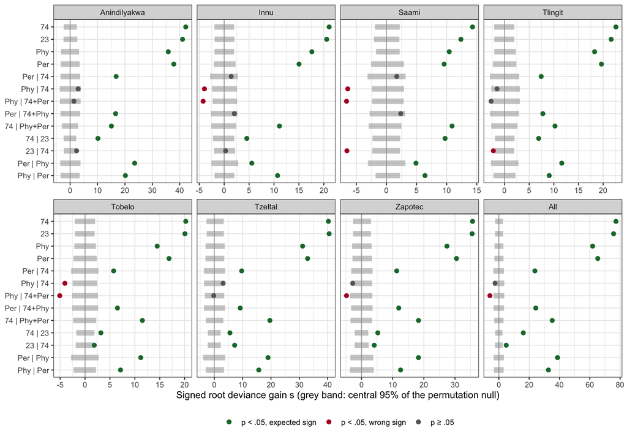

```r
p <- res %>%
  mutate(sig = case_when(p_two < .05 & s_obs > 0 ~ "p < .05, expected sign",
                         p_two < .05 ~ "p < .05, wrong sign",
                         TRUE ~ "p ≥ .05"),
         test = fct_rev(test)) %>%
  ggplot(aes(y = test)) +
  geom_vline(xintercept = 0, colour = "grey70") +
  geom_linerange(aes(xmin = null_q025, xmax = null_q975), colour = "grey60",
                 linewidth = 3, alpha = .5) +
  geom_point(aes(x = s_obs, colour = sig), size = 2) +
  scale_colour_manual(values = c("p < .05, expected sign" = "#1b7837",
                                 "p < .05, wrong sign" = "#b2182b",
                                 "p ≥ .05" = "grey40"), name = NULL) +
  facet_wrap(~ language, nrow = 2, scales = "free_x") +
  labs(x = "Signed root deviance gain s (grey band: central 95% of the permutation null)",
       y = NULL) +
  theme_bw() +
  theme(legend.position = "bottom")
p
```

```r
ggsave(file.path(out_dir, "perm_tests.png"), p, width = 10, height = 7, dpi = 150)
```

# 1974 vs 2023: category bootstrap

The encompassing tests above ask whether each taxonomy carries information the other lacks. They don’t give an effect size for “how much better is 1974?” with uncertainty that reflects the category structure. For that, the folk categories were resampled with replacement within each language, and LL(74) − LL(23) was recomputed on each resample (2000 resamples). Large categories contribute many same-name pairs, so the result depends heavily on which of them are drawn. The interval shows how much. The differences are rescaled to the original number of pairs.

```r
boot_tab <- summarise_boot(boot$boot, boot$observed) %>%
  mutate(language = factor(language, lang_order)) %>%
  arrange(language)
write.csv(boot_tab, file.path(out_dir, "table_boot_74v23.csv"), row.names = FALSE)

boot_tab %>%
  transmute(Language = language, `Observed ΔLL` = fmt(observed),
            `Bootstrap SD` = fmt(boot_sd),
            `95% interval` = paste0("[", fmt(ci_lo), ", ", fmt(ci_hi), "]"),
            `% favouring 74` = fmt(pct_favour_74, 0)) %>%
  kable(align = c("l", "r", "r", "r", "r"),
        caption = "LL(74) − LL(23): observed and category-bootstrap percentile interval") %>%
  kable_styling(full_width = FALSE)
```

LL(74) − LL(23): observed and category-bootstrap percentile interval

| Language | Observed ΔLL | Bootstrap SD | 95% interval | % favouring 74 |
| --- | --- | --- | --- | --- |
| Anindilyakwa | 48.6 | 66.3 | [-71.3, 183.9] | 79 |
| Innu | 10.3 | 13.4 | [-18.0, 37.0] | 81 |
| Saami | 25.8 | 23.2 | [-15.8, 61.8] | 64 |
| Tlingit | 21.4 | 12.0 | [1.7, 46.5] | 99 |
| Tobelo | 3.3 | 5.5 | [-9.9, 12.9] | 73 |
| Tzeltal | -10.6 | 24.0 | [-58.7, 37.2] | 32 |
| Zapotec | 5.3 | 24.1 | [-44.5, 49.0] | 60 |
| All | 118.3 | 97.0 | [-52.6, 318.2] | 90 |

For comparison, the paper’s ΔBIC for 74 vs 23 is 2 × ΔLL, e.g. 97.2 in Anindilyakwa, and it is read as decisive evidence. The bootstrap SD of 2 × ΔLL there is 132.6.

# Summary

These notes describe the full run (B = 2000). They are written by hand, so re-check them if the settings change.

- **Calibration.** MRQAP’s false-positive rate is close to nominal. The naive test’s rate is about 4–5 times too high.
- **(a)** Every measure predicts name-sharing in every language (p < .001).
- **Per adds to 74** in five languages and in the pooled model. It does not in Innu or Saami.
- **Phy never adds to 74 in the expected direction.** Given 74, or 74 + Per, its slope has a significantly *wrong* sign in several languages and in the pooled model. So the wrong-sign coefficients (A2) are not just noise from collinearity: once taxonomy is controlled, birds that are phylogenetically closer are somewhat *less* likely to share a name.
- **74 adds to Phy + Per** in every language.
- **74 vs 23.** 74 adds to 23 in all seven languages. But 23 also adds to 74 (expected sign) in Tzeltal, Zapotec, Tobelo and the pooled model, so each taxonomy carries something the other lacks. In the category bootstrap, the 95% interval for LL(74) − LL(23) excludes 0 only in Tlingit. Pooled, 90% of resamples favour 74, but the interval includes 0. Most languages lean towards 1974, but how big its advantage is depends on a few large categories. The data don’t support the claim that 1974 is decisively better.

# Limitations

- **The null is “relabel species”.** MRQAP asks whether the observed match between a measure’s residual and the folk names is better than for random relabellings of the same residual. It keeps the dependence in the outcome exactly, but the relabelled residuals don’t keep the clade structure of a real residual (e.g. 74 and 23 differ in a few specific clades). The calibration check suggests the test’s error rate is close to nominal for a predictor with realistic structure.
- **The bootstrap is approximate.** Duplicated categories bring duplicated between-category pairs, and different copies of the same category can’t be paired. Each overdifferentiated species is resampled with its smallest category, and keeps its other memberships through the original `SameName` values (9 memberships in total; 5 in Tobelo).
- **Seven languages.** The pooled tests treat the seven languages as fixed. Whether a result carries over to other folk taxonomies is the question that leave-one-language-out in `cv_analyses/` addresses, with little power.